# Car Insurance Claims Classification Codes

## 4.4 Encoding Categorical Columns

Since later it is realized that data is imbalanced and therefore it should be resampled, it is required that data would only contain numerical columns for the next part. For this reason, one-hot-encoding is applied in the following:

```r
dummy <- dummyVars(" ~ .", data=df)
df_enc <- data.frame(predict(dummy, newdata = df))
dplyr::glimpse(df_enc)
```

```
## Rows: 10,000
## Columns: 34
## $ id                        <dbl> 569520, 750365, 199901, 478866, 731664, 8775…
## $ age.16.25                 <dbl> 0, 1, 1, 1, 0, 0, 0, 0, 0, 0, 0, 0, 0, 1, 0,…
## $ age.26.39                 <dbl> 0, 0, 0, 0, 1, 0, 0, 1, 0, 0, 0, 0, 0, 0, 1,…
## $ age.40.64                 <dbl> 0, 0, 0, 0, 0, 1, 0, 0, 1, 1, 0, 0, 1, 0, 0,…
## $ age.65.                   <dbl> 1, 0, 0, 0, 0, 0, 1, 0, 0, 0, 1, 1, 0, 0, 0,…
## $ gender.female             <dbl> 1, 0, 1, 0, 0, 1, 0, 1, 1, 1, 0, 1, 0, 1, 0,…
## $ gender.male               <dbl> 0, 1, 0, 1, 1, 0, 1, 0, 0, 0, 1, 0, 1, 0, 1,…
## $ race.majority             <dbl> 1, 1, 1, 1, 1, 1, 1, 1, 1, 1, 1, 1, 1, 1, 1,…
## $ race.minority             <dbl> 0, 0, 0, 0, 0, 0, 0, 0, 0, 0, 0, 0, 0, 0, 0,…
## $ driving_experience.0.9y   <dbl> 1, 1, 1, 1, 0, 0, 0, 1, 0, 1, 0, 0, 0, 1, 0,…
## $ driving_experience.10.19y <dbl> 0, 0, 0, 0, 1, 0, 0, 0, 0, 0, 0, 0, 0, 0, 1,…
## $ driving_experience.20.29y <dbl> 0, 0, 0, 0, 0, 1, 0, 0, 1, 0, 0, 0, 1, 0, 0,…
## $ driving_experience.30y.   <dbl> 0, 0, 0, 0, 0, 0, 1, 0, 0, 0, 1, 1, 0, 0, 0,…
```

[output cut: 21 more lines]

Ensuring the encoded dataframe didn’t slip a NA value:

```r
is.na(df_enc) |> colSums()
```

```
##                        id                 age.16.25                 age.26.39
##                         0                         0                         0
##                 age.40.64                   age.65.             gender.female
##                         0                         0                         0
##               gender.male             race.majority             race.minority
##                         0                         0                         0
##   driving_experience.0.9y driving_experience.10.19y driving_experience.20.29y
##                         0                         0                         0
##   driving_experience.30y.     education.high.school            education.none
##                         0                         0                         0
##      education.university       income.middle.class            income.poverty
##                         0                         0                         0
##        income.upper.class      income.working.class              credit_score
##                         0                         0                         0
##         vehicle_ownership   vehicle_year.after.2015  vehicle_year.before.2015
##                         0                         0                         0
##                   married                  children               postal_code
##                         0                         0                         0
##            annual_mileage        vehicle_type.sedan   vehicle_type.sports.car
##                         0                         0                         0
##       speeding_violations                      duis            past_accidents
##                         0                         0                         0
##                   outcome
##                         0
```

## 4.5 Split to Train/Test

```r
df_dict <- train_test_splitter_hmd(df_enc,
                             proportion=0.8,
                             join="id")
train <- df_dict$train
test <- df_dict$test
```

## 4.6 Normalize

```r
for (col in names(train)){
  if (col %in% c("annual_mileage", "postal_code", "credit_score"))
  {
    next
  }
  train[[col]] <- as.integer(train[[col]])
  test[[col]] <- as.integer(test[[col]])
}
```

```r
df_dict_norm <- normalizer_hmd(train,test)


train <- df_dict_norm$train_norm
test <- df_dict_norm$test_norm

train$id <- as.double(train$id)
test$id <- as.double(test$id)
```

```r
print(paste("train data has", nrow(train), "rows and", ncol(train), "columns"))
```

```
## [1] "train data has 8000 rows and 34 columns"
```

```r
print(paste("test data has", nrow(test), "rows and", ncol(test), "columns"))
```

```
## [1] "test data has 2000 rows and 34 columns"
```

## 4.7 Oversampling

The racog alogirthm is used here. Since this part is computationally extensive, the results after this are stored in the package, so most commands from here until applying the models are commented out To access the processed datasets of train and test, with names `insurance_train` and `insurance_test` respectively in the package run the following:

```r
data(insurance_train)
data(insurance_test)
```

```r
#train_racog <- racog(train,
#                     numInstances = 3000,
#                     burnin = 100,
#                     lag = 20,
#                     classAttr = "outcome")
```

Merge new sampled data with original train dataset

```r
#insurance_train <- rbind(train , train_racog)
```

We can compare the new generated classes and old ones:

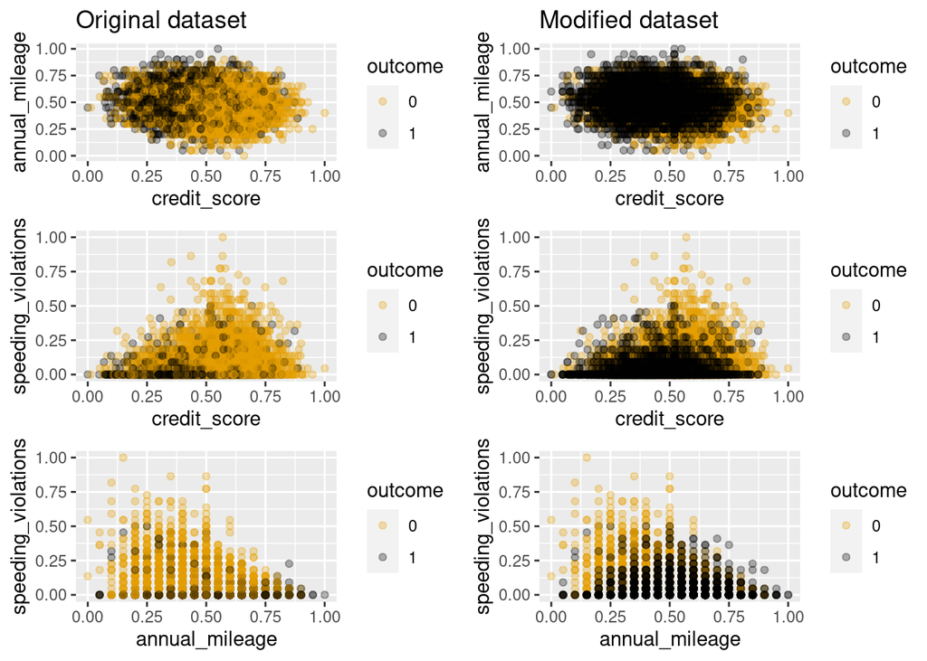

```r
tr <- within(train, rm("id"))
tr$outcome <- as.factor(tr$outcome)

tr2 <- insurance_train
tr2$outcome <- as.factor(tr2$outcome)

imbalance::plotComparison(dataset = tr, anotherDataset = tr2, attrs = c("credit_score", "annual_mileage", "speeding_violations"), classAttr = "outcome")
```

```r
#path = "/home/hamed/Documents/R/aiinsurance/inst/"
#file_name = "insurance_train.csv"
#readr::write_csv(insurance_train,
#                 file = #paste(path,file_name,sep=""))
```

Load back the processed data

```r
#insurance_train <- #readr::read_csv(paste(path,file_name,sep=""))
```

Do the same for test data

```r
#insurance_test <- test
#path = "/home/hamed/Documents/R/aiinsurance/inst/"
#file_name = "insurance_test.csv"
#readr::write_csv(insurance_test,
#                 file = paste(path,file_name,sep=""))

#insurance_test <- #readr::read_csv(paste(path,file_name,sep=""))
```

we need to also remove the id of the beneficiaries as it will bias the learning towards this and may cause data leakage for test datasets with the same id

```r
#insurance_train <- within(insurance_train, rm("id"))
#insurance_test <- within(insurance_test, rm("id"))
```

```r
data("insurance_train")
data("insurance_test")
```

```r
glimpse(insurance_train)
```

```
## Rows: 11,000
## Columns: 33
## $ age.16.25                 <int> 0, 0, 0, 0, 1, 0, 1, 1, 0, 0, 0, 0, 1, 1, 1,…
## $ age.26.39                 <int> 0, 0, 1, 0, 0, 0, 0, 0, 1, 1, 0, 1, 0, 0, 0,…
## $ age.40.64                 <int> 0, 1, 0, 0, 0, 1, 0, 0, 0, 0, 0, 0, 0, 0, 0,…
## $ age.65.                   <int> 1, 0, 0, 1, 0, 0, 0, 0, 0, 0, 1, 0, 0, 0, 0,…
## $ gender.female             <int> 0, 1, 0, 1, 1, 0, 0, 0, 0, 1, 0, 1, 1, 0, 1,…
## $ gender.male               <int> 1, 0, 1, 0, 0, 1, 1, 1, 1, 0, 1, 0, 0, 1, 0,…
## $ race.majority             <int> 1, 1, 1, 1, 0, 1, 0, 1, 0, 1, 1, 1, 1, 1, 1,…
## $ race.minority             <int> 0, 0, 0, 0, 1, 0, 1, 0, 1, 0, 0, 0, 0, 0, 0,…
## $ driving_experience.0.9y   <int> 0, 0, 0, 0, 1, 0, 1, 1, 0, 0, 0, 0, 1, 1, 1,…
## $ driving_experience.10.19y <int> 0, 1, 1, 0, 0, 0, 0, 0, 1, 1, 0, 1, 0, 0, 0,…
## $ driving_experience.20.29y <int> 0, 0, 0, 1, 0, 1, 0, 0, 0, 0, 0, 0, 0, 0, 0,…
## $ driving_experience.30y.   <int> 1, 0, 0, 0, 0, 0, 0, 0, 0, 0, 1, 0, 0, 0, 0,…
## $ education.high.school     <int> 0, 0, 1, 1, 1, 0, 1, 1, 1, 1, 0, 0, 1, 0, 0,…
```

[output cut: 20 more lines]

```r
glimpse(insurance_test)
```

```
## Rows: 2,000
## Columns: 33
## $ age.16.25                 <int> 0, 0, 0, 0, 0, 0, 1, 1, 0, 0, 0, 0, 0, 1, 0,…
## $ age.26.39                 <int> 0, 0, 0, 0, 1, 0, 0, 0, 0, 0, 1, 0, 0, 0, 0,…
## $ age.40.64                 <int> 1, 0, 0, 1, 0, 0, 0, 0, 1, 1, 0, 0, 0, 0, 1,…
## $ age.65.                   <int> 0, 1, 1, 0, 0, 1, 0, 0, 0, 0, 0, 1, 1, 0, 0,…
## $ gender.female             <int> 1, 0, 1, 0, 1, 0, 0, 1, 0, 0, 0, 0, 0, 0, 1,…
## $ gender.male               <int> 0, 1, 0, 1, 0, 1, 1, 0, 1, 1, 1, 1, 1, 1, 0,…
## $ race.majority             <int> 1, 1, 1, 1, 1, 1, 1, 1, 1, 1, 1, 1, 1, 1, 1,…
## $ race.minority             <int> 0, 0, 0, 0, 0, 0, 0, 0, 0, 0, 0, 0, 0, 0, 0,…
## $ driving_experience.0.9y   <int> 0, 0, 0, 0, 1, 0, 1, 1, 0, 0, 0, 0, 0, 1, 0,…
## $ driving_experience.10.19y <int> 0, 0, 0, 0, 0, 0, 0, 0, 1, 0, 1, 0, 0, 0, 0,…
## $ driving_experience.20.29y <int> 1, 0, 0, 1, 0, 0, 0, 0, 0, 1, 0, 0, 0, 0, 1,…
## $ driving_experience.30y.   <int> 0, 1, 1, 0, 0, 1, 0, 0, 0, 0, 0, 1, 1, 0, 0,…
## $ education.high.school     <int> 1, 1, 1, 1, 1, 0, 0, 1, 1, 1, 1, 0, 1, 0, 0,…
```

[output cut: 20 more lines]

```r
table(insurance_train$outcome)
```

```
##
##    0    1
## 5484 5516
```

```r
imbalance::imbalanceRatio(insurance_train, classAttr = "outcome")
```

```
## [1] 0.9941987
```

Data Visualisation

```r
#insurance_train |> ggplot(aes(x = credit_score, y = #speeding_violations)) +
#  geom_point(color = outcome)
```

# 5 **Classification Models**

## 5.1 **Generalized Linear Models**

```r
actual <- insurance_test$outcome
```

**GLM**

```r
fit <- glm_fit_hmd(insurance_train, target="outcome", family="binomial")
h <- glm_predict_hmd(fit,
                        data = insurance_test,
                        target = "outcome")
coef = h$coef
pred_glm <- h$predictions
pred_proba_glm <- h$predict_proba
```

```r
summary(fit)
```

```
##
## Call:
## stats::glm(formula = glm_format, family = {
##     {
##         family
##     }
## }, data = df)
##
## Deviance Residuals:
##     Min       1Q   Median       3Q      Max
## -3.2941  -0.5332   0.0968   0.5764   3.2898
##
## Coefficients: (4 not defined because of singularities)
##                           Estimate Std. Error z value Pr(>|z|)
## (Intercept)                0.17229    0.33125   0.520 0.602967
## age.16.25                  0.12188    0.11505   1.059 0.289454
## age.26.39                 -0.13679    0.09681  -1.413 0.157657
## age.40.64                 -0.27321    0.10319  -2.648 0.008105 **
## age.65.                   -0.12704    0.12689  -1.001 0.316755
## gender.female             -0.90848    0.05888 -15.430  < 2e-16 ***
## gender.male                     NA         NA      NA       NA
## race.majority              0.11025    0.09034   1.220 0.222292
## race.minority                   NA         NA      NA       NA
## driving_experience.0.9y    2.25425    0.18599  12.120  < 2e-16 ***
## driving_experience.10.19y  0.55940    0.17247   3.243 0.001181 **
## driving_experience.20.29y -1.04472    0.18714  -5.583 2.37e-08 ***
## driving_experience.30y.   -1.65633    0.26683  -6.207 5.39e-10 ***
## education.high.school      0.20773    0.11088   1.873 0.061006 .
## education.none             0.38751    0.10403   3.725 0.000195 ***
## education.university       0.16342    0.10899   1.499 0.133778
## income.middle.class        0.19168    0.09211   2.081 0.037448 *
## income.poverty             0.25226    0.11247   2.243 0.024908 *
## income.upper.class         0.17092    0.10740   1.591 0.111518
## income.working.class       0.40319    0.09166   4.399 1.09e-05 ***
## credit_score              -0.14892    0.26484  -0.562 0.573910
## vehicle_ownership         -1.55159    0.06183 -25.095  < 2e-16 ***
## vehicle_year.after.2015   -1.65975    0.07259 -22.865  < 2e-16 ***
## vehicle_year.before.2015        NA         NA      NA       NA
## married                   -0.45440    0.06346  -7.161 8.03e-13 ***
## children                  -0.26748    0.06318  -4.233 2.30e-05 ***
## postal_code                1.73352    0.12759  13.586  < 2e-16 ***
## annual_mileage             1.19594    0.25215   4.743 2.11e-06 ***
## vehicle_type.sedan        -0.17842    0.12571  -1.419 0.155821
## vehicle_type.sports.car         NA         NA      NA       NA
## speeding_violations        1.49235    0.44509   3.353 0.000800 ***
## duis                      -0.16071    0.38786  -0.414 0.678611
## past_accidents            -2.38947    0.45009  -5.309 1.10e-07 ***
## ---
## Signif. codes:  0 '***' 0.001 '**' 0.01 '*' 0.05 '.' 0.1 ' ' 1
##
## (Dispersion parameter for binomial family taken to be 1)
##
##     Null deviance: 15249.1  on 10999  degrees of freedom
## Residual deviance:  8434.7  on 10971  degrees of freedom
## AIC: 8492.7
##
## Number of Fisher Scoring iterations: 6
```

Interpreting the results of a binomial generalized linear model (GLM) fit with the can be done by looking at the coefficients of the model and their corresponding significance levels. The coefficients represent the change in the log-odds of the outcome for a one-unit change in the predictor variable, holding all other predictors constant. The significance levels of the coefficients can be determined by looking at the p-values, with smaller p-values indicating stronger evidence against the null hypothesis that the coefficient is equal to zero.

The following columns had p-value less than $2e-16$:

- `driving_experience.0.9y`
- `vehicle_ownership`
- `vehicle_year.after.2015`
- `postal_code`
- `gender.female`

From `coef` we can detect whether the mentioned columns had positive or negative impact on the predictions.

```r
coef
```

```
##               (Intercept)                 age.16.25                 age.26.39
##                 0.1722946                 0.1218785                -0.1367859
##                 age.40.64                   age.65.             gender.female
##                -0.2732099                -0.1270374                -0.9084817
##               gender.male             race.majority             race.minority
##                        NA                 0.1102514                        NA
##   driving_experience.0.9y driving_experience.10.19y driving_experience.20.29y
##                 2.2542490                 0.5593966                -1.0447194
##   driving_experience.30y.     education.high.school            education.none
##                -1.6563349                 0.2077277                 0.3875125
##      education.university       income.middle.class            income.poverty
##                 0.1634237                 0.1916752                 0.2522558
##        income.upper.class      income.working.class              credit_score
##                 0.1709167                 0.4031949                -0.1489177
##         vehicle_ownership   vehicle_year.after.2015  vehicle_year.before.2015
##                -1.5515944                -1.6597537                        NA
##                   married                  children               postal_code
##                -0.4544041                -0.2674758                 1.7335224
##            annual_mileage        vehicle_type.sedan   vehicle_type.sports.car
##                 1.1959431                -0.1784208                        NA
##       speeding_violations                      duis            past_accidents
##                 1.4923479                -0.1607137                -2.3894743
```

```r
head(pred_glm)
```

```
## 1 2 3 4 5 6
## 0 0 0 0 1 0
```

```r
fit$aic
```

```
## [1] 8492.693
```

**GLMNET**

```r
fit <- glmnet_fit_hmd(insurance_train,
                      target="outcome",
                      family="binomial")
h <- glm_predict_hmd(fit,
                     data = insurance_test,
                     target = "outcome",
                     s=0.5)
coef = h$coef
pred_glmnet <- h$predictions
pred_proba_glmnet <- h$predict_proba
```

Any `s` value that is not close to zero will yield a prediction which always predicts class 1, and hence it would perform poorly.

**cross validated GLMNET**

**min**

```r
fit <- glmnet_cv_fit_hmd(insurance_train, target="outcome", family="binomial")
h <- glmnet_cv_predict_hmd(fit,
                           data = insurance_test,
                           target = "outcome",
                           lchoice = "min")
coef = h$coef
pred_glm_cv_min <- h$predictions
pred_proba_glm_cv_min <- h$predict_proba
```

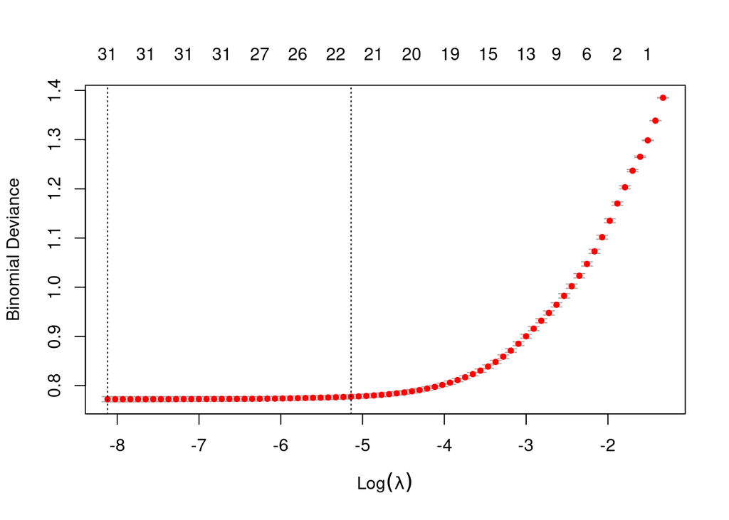

```r
glmnet_cv_plot_hmd(fit)
```

```r
summary(fit)
```

```
##            Length Class  Mode
## lambda     74     -none- numeric
## cvm        74     -none- numeric
## cvsd       74     -none- numeric
## cvup       74     -none- numeric
## cvlo       74     -none- numeric
## nzero      74     -none- numeric
## call        4     -none- call
## name        1     -none- character
## glmnet.fit 13     lognet list
## lambda.min  1     -none- numeric
## lambda.1se  1     -none- numeric
## index       2     -none- numeric
```

```r
coef
```

```
## 33 x 1 sparse Matrix of class "dgCMatrix"
##                                      s1
## (Intercept)                2.606699e-01
## age.16.25                  1.470227e-01
## age.26.39                 -1.053756e-01
## age.40.64                 -2.477387e-01
## age.65.                   -9.772754e-02
## gender.female             -9.024817e-01
## gender.male                5.554381e-05
## race.majority              1.002116e-01
## race.minority              .
## driving_experience.0.9y    2.191045e+00
## driving_experience.10.19y  5.082683e-01
## driving_experience.20.29y -1.064324e+00
## driving_experience.30y.   -1.649878e+00
## education.high.school      1.627430e-01
## education.none             3.502781e-01
## education.university       1.262105e-01
## income.middle.class        1.579856e-01
## income.poverty             2.240788e-01
## income.upper.class         1.266337e-01
## income.working.class       3.765955e-01
## credit_score              -1.131380e-01
## vehicle_ownership         -1.540379e+00
## vehicle_year.after.2015   -1.644180e+00
## vehicle_year.before.2015   4.626151e-12
## married                   -4.489660e-01
## children                  -2.668132e-01
## postal_code                1.714963e+00
## annual_mileage             1.160143e+00
## vehicle_type.sedan        -1.672808e-01
## vehicle_type.sports.car    1.407297e-13
## speeding_violations        1.359474e+00
## duis                      -1.350778e-01
## past_accidents            -2.372703e+00
```

```r
head(pred_glm_cv_min)
```

```
##      lambda.min
## [1,]          0
## [2,]          0
## [3,]          0
## [4,]          0
## [5,]          1
## [6,]          0
```

Extract AIC and BIC from the fit of glm

```r
glmnet_cv_aic_hmd(fit, lchoice = "min")
```

```
## $AICc
## [1] -6751.432
##
## $BIC
## [1] -6525.138
```

**GLMNET**

**1SE**

```r
fit <- glmnet_cv_fit_hmd(insurance_train, target="outcome", family="binomial")
h <- glmnet_cv_predict_hmd(fit,
                           data = insurance_test,
                           target = "outcome",
                           lchoice = "1se")
coef = h$coef
pred_glm_cv_1se <- h$predictions
pred_proba_glm_cv_1se <- h$predict_proba
```

```r
summary(fit)
```

```
##            Length Class  Mode
## lambda     74     -none- numeric
## cvm        74     -none- numeric
## cvsd       74     -none- numeric
## cvup       74     -none- numeric
## cvlo       74     -none- numeric
## nzero      74     -none- numeric
## call        4     -none- call
## name        1     -none- character
## glmnet.fit 13     lognet list
## lambda.min  1     -none- numeric
## lambda.1se  1     -none- numeric
## index       2     -none- numeric
```

```r
coef
```

```
## 33 x 1 sparse Matrix of class "dgCMatrix"
##                                      s1
## (Intercept)                1.018119e+00
## age.16.25                  2.181744e-01
## age.26.39                  .
## age.40.64                 -1.022830e-01
## age.65.                   -7.228297e-04
## gender.female             -7.039896e-01
## gender.male                9.213086e-06
## race.majority              .
## race.minority              .
## driving_experience.0.9y    1.512906e+00
## driving_experience.10.19y  .
## driving_experience.20.29y -1.158297e+00
## driving_experience.30y.   -1.306864e+00
## education.high.school      .
## education.none             1.261959e-01
## education.university       .
## income.middle.class        .
## income.poverty             5.757163e-02
## income.upper.class        -4.045528e-02
## income.working.class       1.615831e-01
## credit_score              -1.235961e-01
## vehicle_ownership         -1.338798e+00
## vehicle_year.after.2015   -1.390326e+00
## vehicle_year.before.2015   4.251933e-12
## married                   -3.962552e-01
## children                  -2.364787e-01
## postal_code                1.231771e+00
## annual_mileage             5.689875e-01
## vehicle_type.sedan         .
## vehicle_type.sports.car    .
## speeding_violations        .
## duis                       .
## past_accidents            -1.830717e+00
```

```r
head(pred_glm_cv_1se)
```

```
##      lambda.1se
## [1,]          0
## [2,]          0
## [3,]          0
## [4,]          0
## [5,]          1
## [6,]          0
```

Extract AIC and BIC from the fit of glm

```r
glmnet_cv_aic_hmd(fit, lchoice = "1se")
```

```
## $AICc
## [1] -6634.007
##
## $BIC
## [1] -6480.673
```

### 5.1.1 Plot

```r
#plot(outcome ~ )
```

### 5.1.2 Evaluate

**GLM**

```r
eval <- eval_hmd(actual, pred_glm)
```

```r
print("confusion matrix: ")
```

```
## [1] "confusion matrix: "
```

```r
print(eval$confusion_matrix)
```

```
## Confusion Matrix and Statistics
##
##           Reference
## Prediction    0    1
##          0 1102   96
##          1  281  521
##
##                Accuracy : 0.8115
##                  95% CI : (0.7937, 0.8284)
##     No Information Rate : 0.6915
##     P-Value [Acc > NIR] : < 2.2e-16
##
##                   Kappa : 0.5921
##
##  Mcnemar's Test P-Value : < 2.2e-16
##
##             Sensitivity : 0.7968
##             Specificity : 0.8444
##          Pos Pred Value : 0.9199
##          Neg Pred Value : 0.6496
##              Prevalence : 0.6915
##          Detection Rate : 0.5510
##    Detection Prevalence : 0.5990
##       Balanced Accuracy : 0.8206
##
##        'Positive' Class : 0
##
```

```r
print("accuracy: ")
```

```
## [1] "accuracy: "
```

```r
print(eval$accuracy)
```

```
## [1] 0.8115
```

```r
print("precision: ")
```

```
## [1] "precision: "
```

```r
print(eval$precision)
```

```
## [1] 0.8444084
```

```r
print("recall: ")
```

```
## [1] "recall: "
```

```r
print(eval$recall)
```

```
## [1] 0.6496259
```

```r
print("f1_score")
```

```
## [1] "f1_score"
```

```r
print(eval$f1_score)
```

```
## [1] 1
```

```r
print("fbeta_score")
```

```
## [1] "fbeta_score"
```

```r
print(eval$fbeta_score)
```

```
## [1] 0.7343199
```

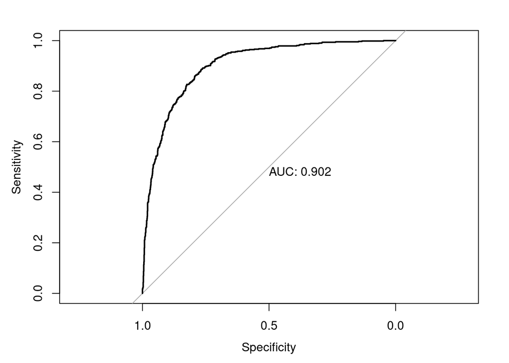

```
##
## Call:
## roc.formula(formula = actual ~ pred_proba_glm, plot = TRUE, print.auc = TRUE)
##
## Data: pred_proba_glm in 1383 controls (actual 0) < 617 cases (actual 1).
## Area under the curve: 0.9017
```

```r
pROC::roc(actual ~ pred_proba_glm, plot = TRUE, print.auc = TRUE)
```

Plot Confusion Matrix

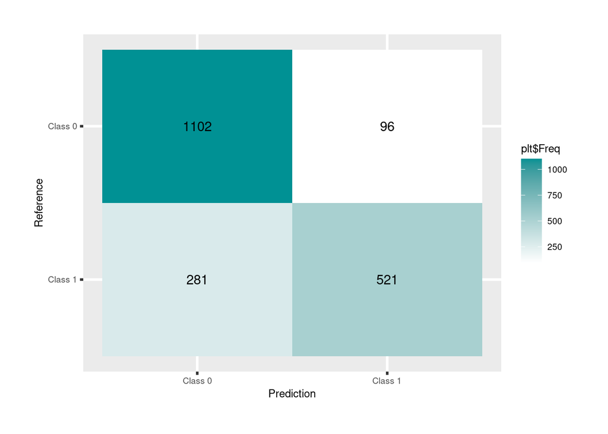

```r
eval$confusion_matrix_plot
```

**GLMNET**

```r
eval <- eval_hmd(actual, pred_glmnet)
print("confusion matrix: ")
```

```
## [1] "confusion matrix: "
```

```r
print(eval$confusion_matrix)
```

```
## Confusion Matrix and Statistics
##
##           Reference
## Prediction    0    1
##          0    0    0
##          1 1383  617
##
##                Accuracy : 0.3085
##                  95% CI : (0.2883, 0.3293)
##     No Information Rate : 0.6915
##     P-Value [Acc > NIR] : 1
##
##                   Kappa : 0
##
##  Mcnemar's Test P-Value : <2e-16
##
##             Sensitivity : 0.0000
##             Specificity : 1.0000
##          Pos Pred Value :    NaN
##          Neg Pred Value : 0.3085
##              Prevalence : 0.6915
##          Detection Rate : 0.0000
##    Detection Prevalence : 0.0000
##       Balanced Accuracy : 0.5000
##
##        'Positive' Class : 0
##
```

```r
print("accuracy: ")
```

```
## [1] "accuracy: "
```

```r
print(eval$accuracy)
```

```
## [1] 0.3085
```

```r
print("precision: ")
```

```
## [1] "precision: "
```

```r
print(eval$precision)
```

```
## [1] 1
```

```r
print("recall: ")
```

```
## [1] "recall: "
```

```r
print(eval$recall)
```

```
## [1] 0.3085
```

```r
print("f1_score")
```

```
## [1] "f1_score"
```

```r
print(eval$f1_score)
```

```
## [1] 0.6666667
```

```r
print("fbeta_score")
```

```
## [1] "fbeta_score"
```

```r
print(eval$fbeta_score)
```

```
## [1] 0.4715323
```

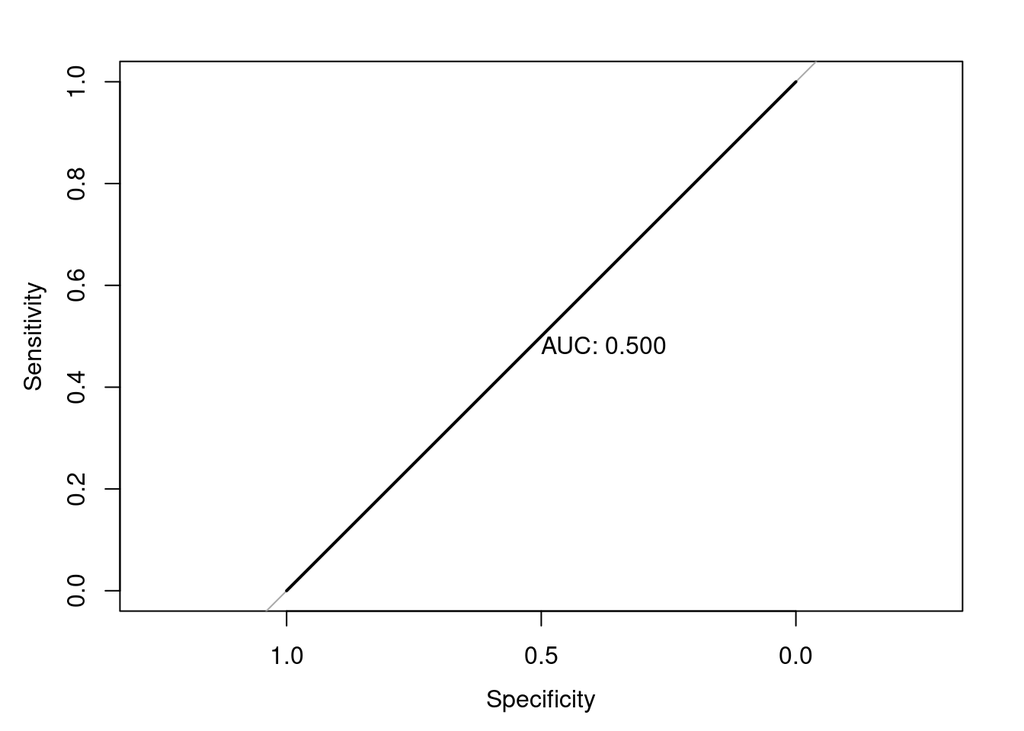

```
##
## Call:
## roc.formula(formula = actual ~ pred_proba_glmnet, plot = TRUE,     print.auc = TRUE)
##
## Data: pred_proba_glmnet in 1383 controls (actual 0) < 617 cases (actual 1).
## Area under the curve: 0.5
```

```r
pROC::roc(actual ~ pred_proba_glmnet, plot = TRUE, print.auc = TRUE)
```

Plot Confusion Matrix

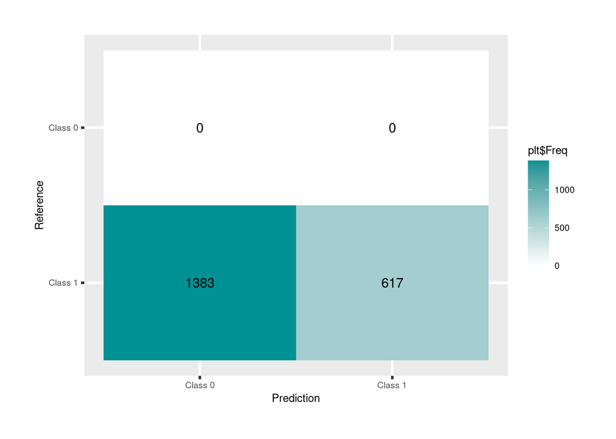

```r
eval$confusion_matrix_plot
```

**GLMNET CV**

**min**

Confusion Matrix

```r
eval <- eval_hmd(actual, pred_glm_cv_min)
```

```r
print("confusion matrix: ")
```

```
## [1] "confusion matrix: "
```

```r
print(eval$confusion_matrix)
```

```
## Confusion Matrix and Statistics
##
##           Reference
## Prediction    0    1
##          0 1104   96
##          1  279  521
##
##                Accuracy : 0.8125
##                  95% CI : (0.7947, 0.8294)
##     No Information Rate : 0.6915
##     P-Value [Acc > NIR] : < 2.2e-16
##
##                   Kappa : 0.5939
##
##  Mcnemar's Test P-Value : < 2.2e-16
##
##             Sensitivity : 0.7983
##             Specificity : 0.8444
##          Pos Pred Value : 0.9200
##          Neg Pred Value : 0.6512
##              Prevalence : 0.6915
##          Detection Rate : 0.5520
##    Detection Prevalence : 0.6000
##       Balanced Accuracy : 0.8213
##
##        'Positive' Class : 0
##
```

```r
print("accuracy: ")
```

```
## [1] "accuracy: "
```

```r
print(eval$accuracy)
```

```
## [1] 0.8125
```

```r
print("precision: ")
```

```
## [1] "precision: "
```

```r
print(eval$precision)
```

```
## [1] 0.8444084
```

```r
print("recall: ")
```

```
## [1] "recall: "
```

```r
print(eval$recall)
```

```
## [1] 0.65125
```

```r
print("f1_score")
```

```
## [1] "f1_score"
```

```r
print(eval$f1_score)
```

```
## [1] 1
```

```r
print("fbeta_score")
```

```
## [1] "fbeta_score"
```

```r
print(eval$fbeta_score)
```

```
## [1] 0.7353564
```

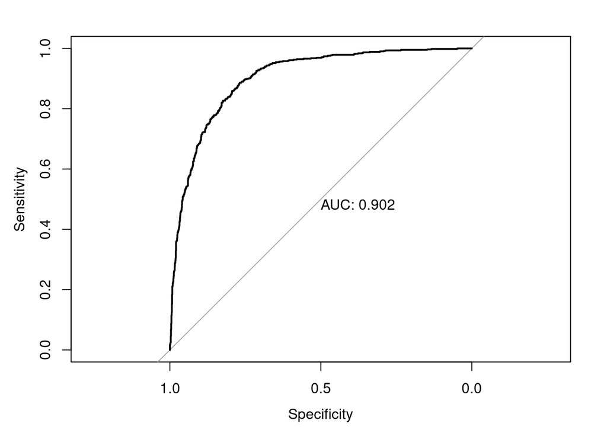

```
##
## Call:
## roc.formula(formula = actual ~ pred_proba_glm_cv_min, plot = TRUE,     print.auc = TRUE)
##
## Data: pred_proba_glm_cv_min in 1383 controls (actual 0) < 617 cases (actual 1).
## Area under the curve: 0.9017
```

```r
pROC::roc(actual ~ pred_proba_glm_cv_min, plot = TRUE, print.auc = TRUE)
```

Plot Confusion Matrix

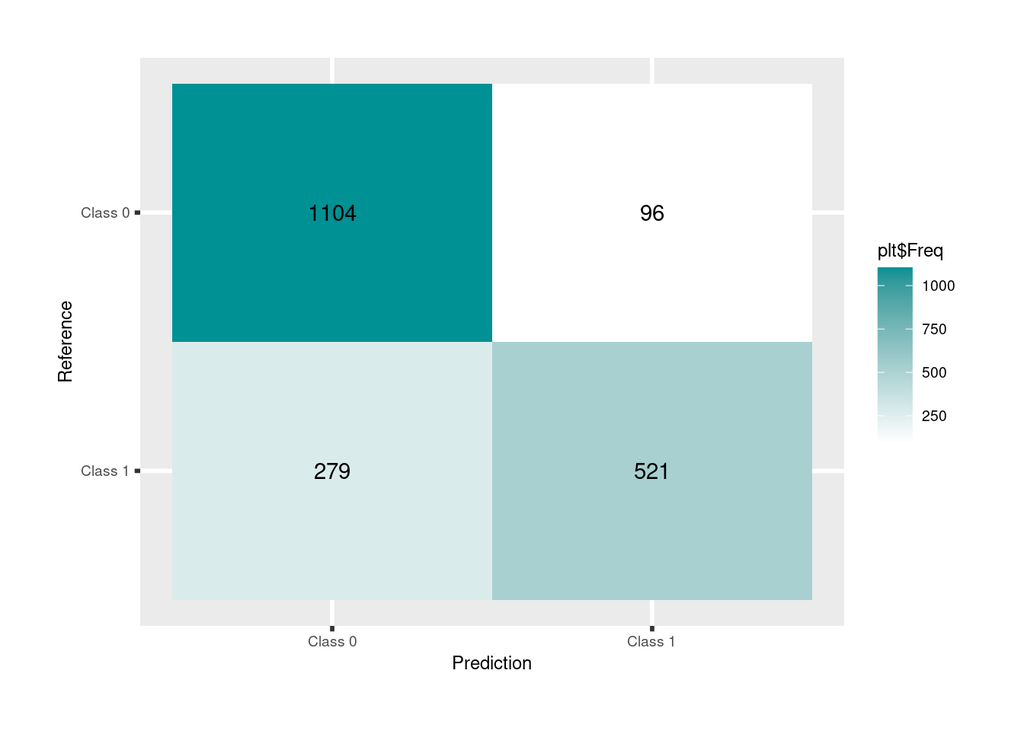

```r
eval$confusion_matrix_plot
```

**1se**

```r
eval <- eval_hmd(actual, pred_glm_cv_1se)
```

```r
print("confusion matrix: ")
```

```
## [1] "confusion matrix: "
```

```r
print(eval$confusion_matrix)
```

```
## Confusion Matrix and Statistics
##
##           Reference
## Prediction    0    1
##          0 1112   92
##          1  271  525
##
##                Accuracy : 0.8185
##                  95% CI : (0.8009, 0.8352)
##     No Information Rate : 0.6915
##     P-Value [Acc > NIR] : < 2.2e-16
##
##                   Kappa : 0.6062
##
##  Mcnemar's Test P-Value : < 2.2e-16
##
##             Sensitivity : 0.8040
##             Specificity : 0.8509
##          Pos Pred Value : 0.9236
##          Neg Pred Value : 0.6595
##              Prevalence : 0.6915
##          Detection Rate : 0.5560
##    Detection Prevalence : 0.6020
##       Balanced Accuracy : 0.8275
##
##        'Positive' Class : 0
##
```

```r
print("accuracy: ")
```

```
## [1] "accuracy: "
```

```r
print(eval$accuracy)
```

```
## [1] 0.8185
```

```r
print("precision: ")
```

```
## [1] "precision: "
```

```r
print(eval$precision)
```

```
## [1] 0.8508914
```

```r
print("recall: ")
```

```
## [1] "recall: "
```

```r
print(eval$recall)
```

```
## [1] 0.6595477
```

```r
print("f1_score")
```

```
## [1] "f1_score"
```

```r
print(eval$f1_score)
```

```
## [1] 1
```

```r
print("fbeta_score")
```

```
## [1] "fbeta_score"
```

```r
print(eval$fbeta_score)
```

```
## [1] 0.7430998
```

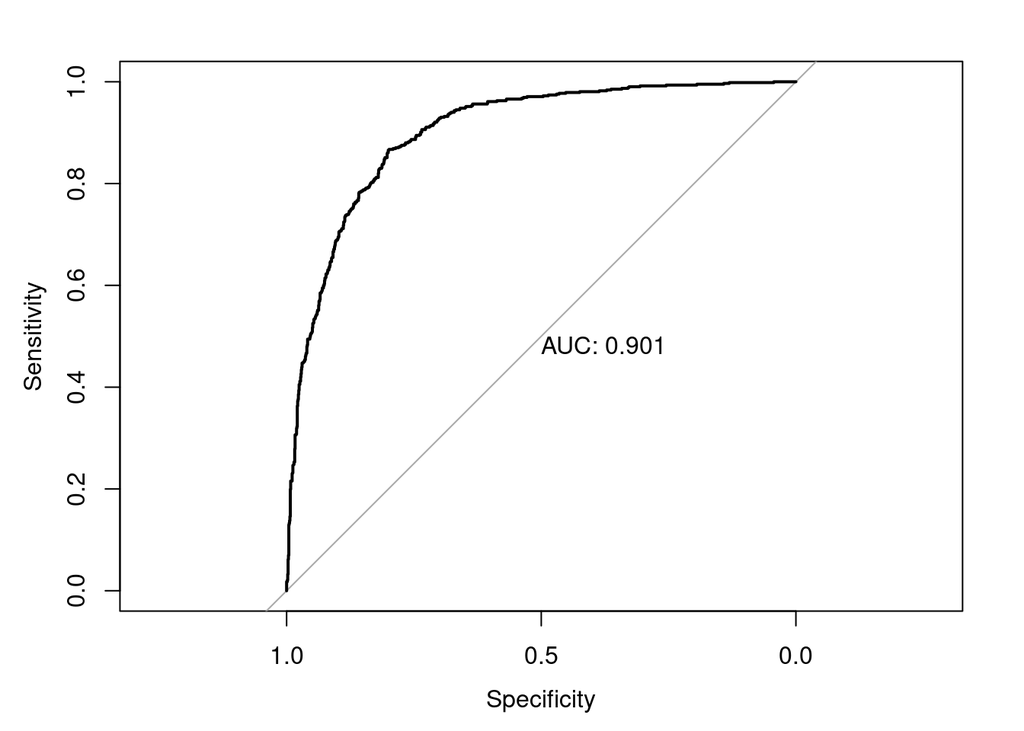

```
##
## Call:
## roc.formula(formula = actual ~ pred_proba_glm_cv_1se, plot = TRUE,     print.auc = TRUE)
##
## Data: pred_proba_glm_cv_1se in 1383 controls (actual 0) < 617 cases (actual 1).
## Area under the curve: 0.9012
```

```r
pROC::roc(actual ~ pred_proba_glm_cv_1se, plot = TRUE, print.auc = TRUE)
```

## 5.2 **Random Forest**

```r
actual <- aiinsurance::insurance_test$outcome
X_train <- aiinsurance::insurance_train[, colnames(aiinsurance::insurance_train)[colnames(aiinsurance::insurance_train) != "outcome"]]
X_test <- aiinsurance::insurance_test[, colnames(aiinsurance::insurance_test)[colnames(aiinsurance::insurance_test) != "outcome"]]
y_train <- as.factor(aiinsurance::insurance_train[["outcome"]])
y_test <- as.factor(aiinsurance::insurance_test[["outcome"]])
```

```r
rf <- rf_fit_hmd(insurance_train,
                 ntree = 300,
                 mtry = 10,
                 proximity = TRUE,
                 importance = TRUE)
```

```r
print(rf)
```

```
##
## Call:
##  randomForest(x = X_train, y = y_train, ntree = {     {         ntree     } }, mtry = {     {         mtry     } }, importance = {     {         importance     } }, proximity = {     {         proximity     } })
##                Type of random forest: classification
##                      Number of trees: 300
## No. of variables tried at each split: 10
##
##         OOB estimate of  error rate: 13.91%
## Confusion matrix:
##      0    1 class.error
## 0 4661  823   0.1500729
## 1  707 4809   0.1281726
```

```r
predict_rf <- rf_predict_hmd(data=insurance_test, fit=rf)
```

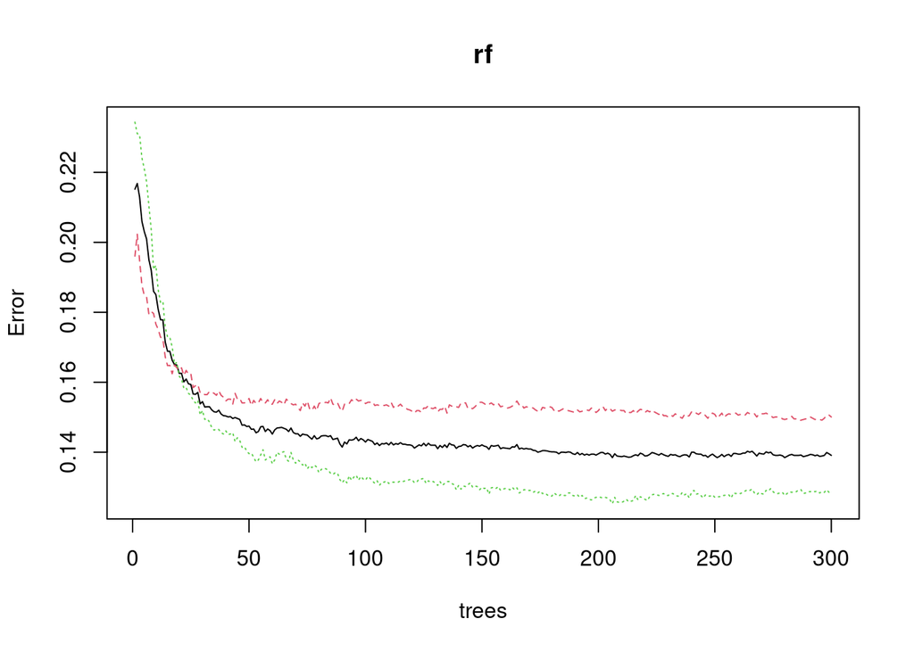

```r
plot(rf)
```

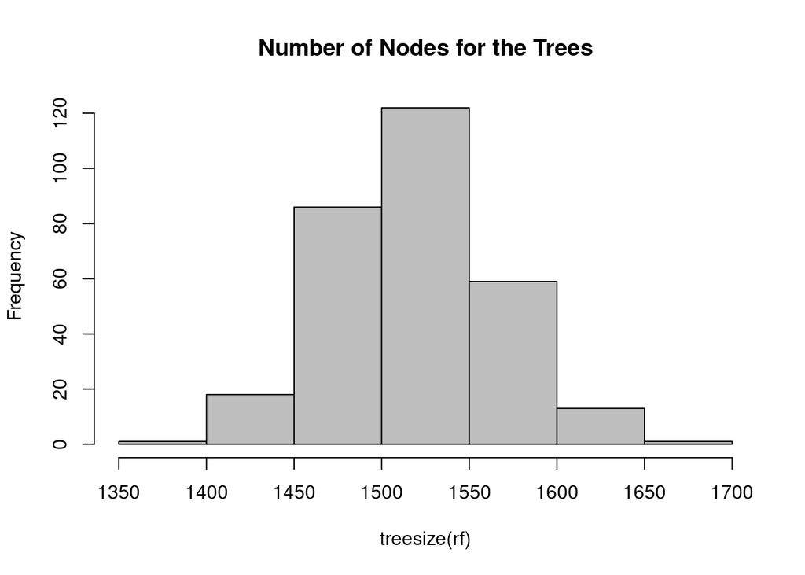

```r
# Number of nodes for the trees
hist(treesize(rf),                        # give us the number of trees in term of number of nodes
     main = "Number of Nodes for the Trees",
     col = "grey")
```

### 5.2.1 Variable Importance

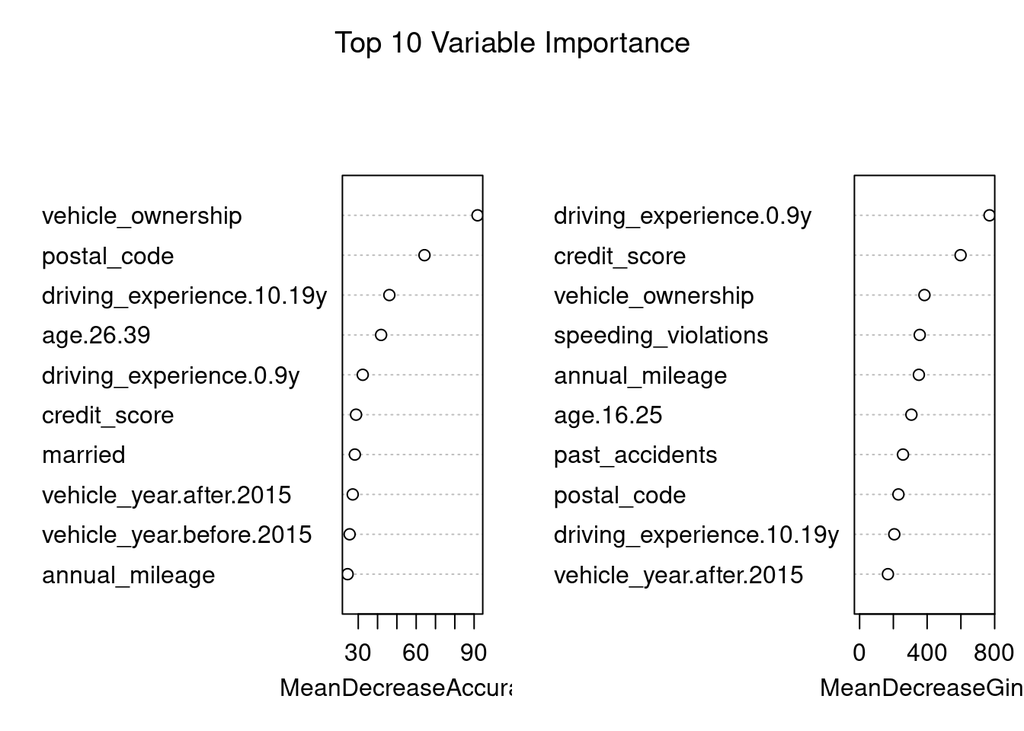

```r
varImpPlot(rf,
           sort = T,
           n.var = 10,
           main = "Top 10 Variable Importance")
```

### 5.2.2 Hyperparameter Tuning

```
## mtry = 5  OOB error = 14.09%
## Searching left ...
## mtry = 10    OOB error = 13.82%
## 0.01935484 0.01
## mtry = 20    OOB error = 14.37%
## -0.04013158 0.01
## Searching right ...
## mtry = 2     OOB error = 15.49%
## -0.1210526 0.01
```

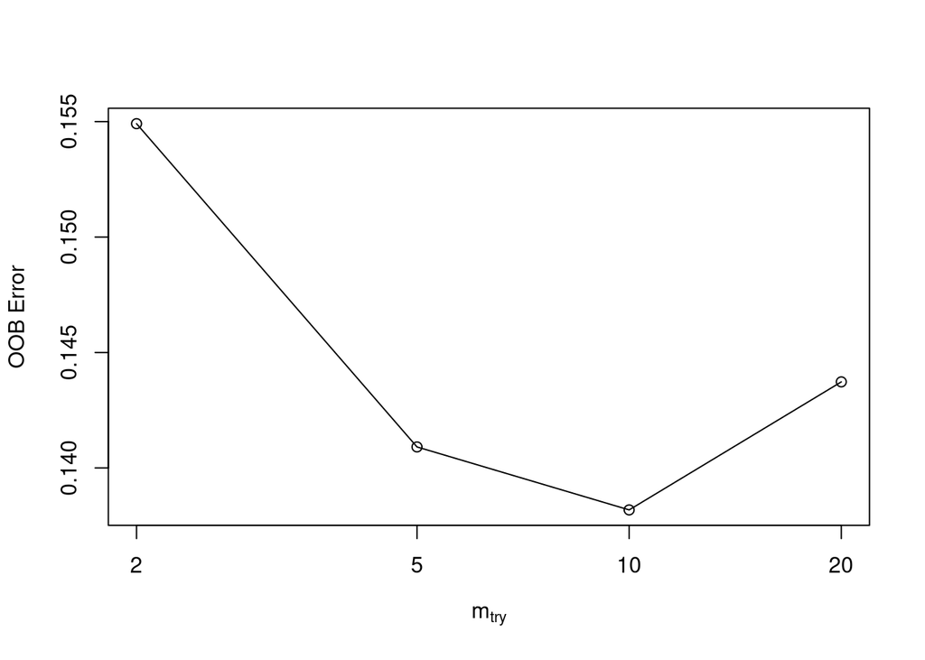

```r
t <- tuneRF(X_train,
            y_train,
            stepFactor = 0.5,
            plot = TRUE,
            ntreeTry = 300,
            trace = TRUE,
            improve = 0.01)
```

```r
print(t)
```

```
##        mtry  OOBError
## 2.OOB     2 0.1549091
## 5.OOB     5 0.1409091
## 10.OOB   10 0.1381818
## 20.OOB   20 0.1437273
```

### 5.2.3 Evaluate

```r
eval <- eval_hmd(actual, predict_rf$predictions_num)
```

```r
print("confusion matrix: ")
```

```
## [1] "confusion matrix: "
```

```r
print(eval$confusion_matrix)
```

```
## Confusion Matrix and Statistics
##
##           Reference
## Prediction    0    1
##          0 1172  123
##          1  211  494
##
##                Accuracy : 0.833
##                  95% CI : (0.8159, 0.8491)
##     No Information Rate : 0.6915
##     P-Value [Acc > NIR] : < 2.2e-16
##
##                   Kappa : 0.6235
##
##  Mcnemar's Test P-Value : 1.932e-06
##
##             Sensitivity : 0.8474
##             Specificity : 0.8006
##          Pos Pred Value : 0.9050
##          Neg Pred Value : 0.7007
##              Prevalence : 0.6915
##          Detection Rate : 0.5860
##    Detection Prevalence : 0.6475
##       Balanced Accuracy : 0.8240
##
##        'Positive' Class : 0
##
```

```r
print("accuracy: ")
```

```
## [1] "accuracy: "
```

```r
print(eval$accuracy)
```

```
## [1] 0.833
```

```r
print("precision: ")
```

```
## [1] "precision: "
```

```r
print(eval$precision)
```

```
## [1] 0.8006483
```

```r
print("recall: ")
```

```
## [1] "recall: "
```

```r
print(eval$recall)
```

```
## [1] 0.7007092
```

```r
print("f1_score")
```

```
## [1] "f1_score"
```

```r
print(eval$f1_score)
```

```
## [1] 1
```

```r
print("fbeta_score")
```

```
## [1] "fbeta_score"
```

```r
print(eval$fbeta_score)
```

```
## [1] 0.7473525
```

```r
pred_proba_rf <- predict_rf$predict_proba
```

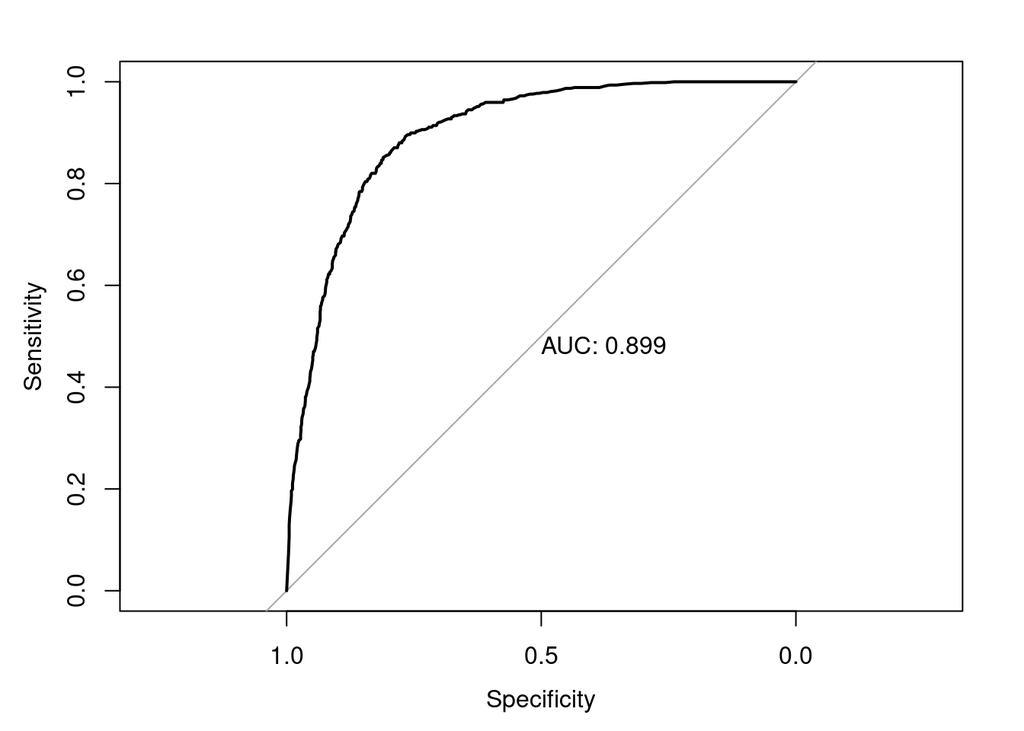

```
##
## Call:
## roc.formula(formula = actual ~ pred_proba_rf, plot = TRUE, print.auc = TRUE)
##
## Data: pred_proba_rf in 1383 controls (actual 0) < 617 cases (actual 1).
## Area under the curve: 0.8992
```

```r
pROC::roc(actual ~ pred_proba_rf, plot = TRUE, print.auc = TRUE)
```

Plot Confusion Matrix

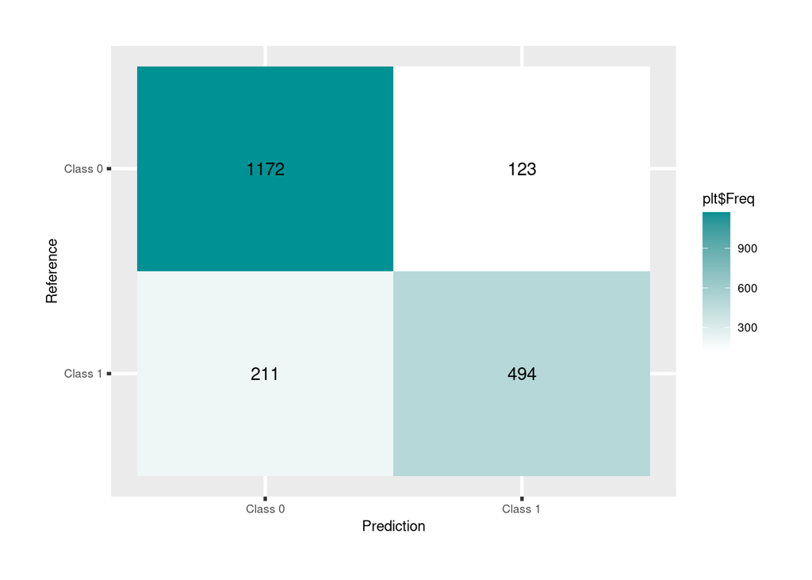

```r
eval$confusion_matrix_plot
```

# 6 Extra Material: Decoding One-Hot-Encoding

```r
col_list <- names(insurance_test)

cols_list_enc <- grep("\\.", col_list, value = TRUE, perl = TRUE)



pattern <- "([a-zA-Z0-9_-]*)(.)"
common_names <- list()
for (col in cols_list_enc)
{
  common_names <- append(common_names, str_match(col, pattern)[2])
}
common_names <- common_names |> unique()

insurance_test_revert <-
insurance_test[, !(colnames(insurance_test) %in% cols_list_enc)]

for (name in common_names){
  cols_revert <- lapply(cols_list_enc,
                      function(x) x[grepl(name, x)])
  cols_revert <- cols_revert[lengths(cols_revert)!=0]
  #cols_revert <- lapply(cols_list_enc,
  #                    function(x) str_match(x,"([\\.])(.*)")[3])

  cols_revert <- cols_revert |> unlist()


  w <- which(insurance_test[cols_revert]==1, arr.ind = T)

  insurance_test_revert_name <- names(insurance_test[cols_revert])[w[order(w[,1]),2]]

  insurance_test_revert[name] <- insurance_test_revert_name

}
```

```r
insurance_test[,0:4] |> tidyr::pivot_longer(col=starts_with("age"), names_to = "age",  names_prefix="age.") |> select(-value)
```

```
## # A tibble: 8,000 × 1
##    age
##    <chr>
##  1 16.25
##  2 26.39
##  3 40.64
##  4 65.
##  5 16.25
##  6 26.39
##  7 40.64
##  8 65.
##  9 16.25
## 10 26.39
## # … with 7,990 more rows
```

```r
insurance_test_revert |> dplyr::glimpse()
```

```
## Rows: 2,000
## Columns: 18
## $ credit_score        <dbl> 0.6234644, 0.6248241, 0.7454570, 0.6432089, 0.7817…
## $ vehicle_ownership   <int> 1, 1, 1, 1, 0, 1, 0, 1, 1, 1, 1, 0, 1, 0, 1, 0, 1,…
## $ married             <int> 0, 1, 1, 1, 1, 1, 1, 0, 0, 1, 0, 0, 1, 0, 1, 0, 1,…
## $ children            <int> 1, 1, 0, 1, 0, 1, 0, 1, 0, 1, 1, 1, 1, 0, 1, 0, 1,…
## $ postal_code         <dbl> 0.0000000, 0.0000000, 0.2751793, 0.0000000, 0.0000…
## $ annual_mileage      <dbl> 0.55, 0.40, 0.50, 0.30, 0.50, 0.50, 0.50, 0.80, 0.…
## $ speeding_violations <dbl> 0.13636364, 0.27272727, 0.18181818, 0.18181818, 0.…
## $ duis                <dbl> 0.0000000, 0.3333333, 0.0000000, 0.1666667, 0.0000…
## $ past_accidents      <dbl> 0.20000000, 0.46666667, 0.00000000, 0.13333333, 0.…
## $ outcome             <int> 0, 0, 0, 0, 0, 0, 1, 1, 0, 0, 0, 0, 0, 1, 0, 1, 1,…
## $ age                 <chr> "age.40.64", "age.65.", "age.65.", "age.40.64", "a…
## $ gender              <chr> "gender.female", "gender.male", "gender.female", "…
## $ race                <chr> "race.majority", "race.majority", "race.majority",…
## $ driving_experience  <chr> "driving_experience.20.29y", "driving_experience.3…
## $ education           <chr> "education.high.school", "education.high.school", …
## $ income              <chr> "income.upper.class", "income.upper.class", "incom…
## $ vehicle_year        <chr> "vehicle_year.after.2015", "vehicle_year.after.201…
## $ vehicle_type        <chr> "vehicle_type.sedan", "vehicle_type.sedan", "vehic…
```